# Client Report - Star Wars Survey Income Classifier

- Show All Code
- Hide All Code

Course DS 250

Author

Wil Jones

## Task 1 - Shorten the column names and clean them up for easier use with pandas. Provide a table or list that exemplifies how you fixed the names.

```python
import pandas as pd
import numpy as np
from sklearn.model_selection import train_test_split
from sklearn.preprocessing import OrdinalEncoder, MinMaxScaler
from sklearn.feature_selection import SelectKBest, f_classif
from sklearn.metrics import accuracy_score, recall_score, precision_score, f1_score, classification_report
from xgboost import XGBClassifier
from lightgbm import LGBMClassifier
from sklearn.ensemble import VotingClassifier
from sklearn.impute import SimpleImputer

# Load data
url = "https://github.com/fivethirtyeight/data/raw/master/star-wars-survey/StarWars.csv"
df = pd.read_csv("https://github.com/fivethirtyeight/data/raw/master/star-wars-survey/StarWars.csv", encoding="ISO-8859-1")

df = df.drop(index=0).reset_index(drop=True)

# Rename columns
# Original and renamed columns
original_to_renamed = {
    df.columns[0]: "RespondentID",
    df.columns[1]: "SeenAnyMovies",
    df.columns[2]: "Fan",
    df.columns[3]: "Seen_EP1",
    df.columns[4]: "Seen_EP2",
    df.columns[5]: "Seen_EP3",
    df.columns[6]: "Seen_EP4",
    df.columns[7]: "Seen_EP5",
    df.columns[8]: "Seen_EP6",
    df.columns[9]: "Rank_EP1",
    df.columns[10]: "Rank_EP2",
    df.columns[11]: "Rank_EP3",
    df.columns[12]: "Rank_EP4",
    df.columns[13]: "Rank_EP5",
    df.columns[14]: "Rank_EP6",
    df.columns[29]: "ShotFirst",
    df.columns[30]: "Know_EU",
    df.columns[31]: "Fan_EU",
    df.columns[32]: "Fan_Trek",
    df.columns[33]: "Gender",
    df.columns[34]: "Age",
    df.columns[35]: "Income",
    df.columns[36]: "Education",
    df.columns[37]: "Region"
}

# Rename columns
df = df.rename(columns=original_to_renamed)

# Show changes in a table
column_changes = pd.DataFrame(list(original_to_renamed.items()), columns=["Original Name", "Renamed To"])
display(column_changes)
```

|  | Original Name | Renamed To |
| --- | --- | --- |
| 0 | RespondentID | RespondentID |
| 1 | Have you seen any of the 6 films in the Star W... | SeenAnyMovies |
| 2 | Do you consider yourself to be a fan of the St... | Fan |
| 3 | Which of the following Star Wars films have yo... | Seen_EP1 |
| 4 | Unnamed: 4 | Seen_EP2 |
| 5 | Unnamed: 5 | Seen_EP3 |
| 6 | Unnamed: 6 | Seen_EP4 |
| 7 | Unnamed: 7 | Seen_EP5 |
| 8 | Unnamed: 8 | Seen_EP6 |
| 9 | Please rank the Star Wars films in order of pr... | Rank_EP1 |
| 10 | Unnamed: 10 | Rank_EP2 |
| 11 | Unnamed: 11 | Rank_EP3 |
| 12 | Unnamed: 12 | Rank_EP4 |
| 13 | Unnamed: 13 | Rank_EP5 |
| 14 | Unnamed: 14 | Rank_EP6 |
| 15 | Which character shot first? | ShotFirst |
| 16 | Are you familiar with the Expanded Universe? | Know_EU |
| 17 | Do you consider yourself to be a fan of the Ex... | Fan_EU |
| 18 | Do you consider yourself to be a fan of the St... | Fan_Trek |
| 19 | Gender | Gender |
| 20 | Age | Age |
| 21 | Household Income | Income |
| 22 | Education | Education |
| 23 | Location (Census Region) | Region |

## Task 2 - Clean and format the data so that it can be used in a machine learning model. As you format the data, you should complete each item listed below. In your final report provide example(s) of the reformatted data with a short description of the changes made.

To prepare the data for modeling, I performed several key transformations. I mapped age ranges and education levels to numeric values, converted income ranges into numerical estimates, and then engineered a binary target variable indicating whether a respondent earns over $50,000 annually. Additional features such as the number of Star Wars movies seen (SeenCount) and the standard deviation of a respondent’s movie rankings (RankStd) were created to enhance model performance. After these transformations, I dropped non-essential columns like raw income and textual identifiers to ensure the dataset was numeric and clean—ready for machine learning.

```python
# Filter: only keep respondents who saw at least one movie
df = df[df["SeenAnyMovies"].str.strip().str.lower() == "yes"]

# Convert age range to numeric
age_map = {"18-29": 24, "30-44": 37, "45-60": 52, "60+": 65}
df["AgeNum"] = df["Age"].map(age_map)

# Convert education to numeric
edu_map = {
    "Less than high school degree": 1,
    "High school degree": 2,
    "Some college or Associate degree": 3,
    "Bachelor degree": 4,
    "Graduate degree": 5
}
df["EduNum"] = df["Education"].map(edu_map)

# Convert income to numeric
def income_to_numeric(val):
    if pd.isna(val): return np.nan
    val = val.strip()
    if val == "Prefer not to answer": return np.nan
    return {
        "$0 - $24,999": 12500,
        "$25,000 - $49,999": 37500,
        "$50,000 - $99,999": 75000,
        "$100,000 - $149,999": 125000,
        "$150,000+": 150000
    }.get(val, np.nan)

# Apply income mapping
df["IncomeNum"] = df["Income"].apply(income_to_numeric)

# Create binary target
df["IncomeOver50k"] = df["IncomeNum"] > 50000

# Engineer features
df["SeenCount"] = df[["Seen_EP1", "Seen_EP2", "Seen_EP3", "Seen_EP4", "Seen_EP5", "Seen_EP6"]].apply(lambda row: row.eq("Yes").sum(), axis=1)
df["RankStd"] = df[["Rank_EP1", "Rank_EP2", "Rank_EP3", "Rank_EP4", "Rank_EP5", "Rank_EP6"]].astype(float).std(axis=1)

# Drop columns no longer needed
df.drop(columns=["RespondentID", "Income", "Age", "Education", "SeenAnyMovies", "IncomeNum"], inplace=True)
```

## Task 3 - Validate that the data provided on GitHub lines up with the article by recreating 2 of the visuals from the article.

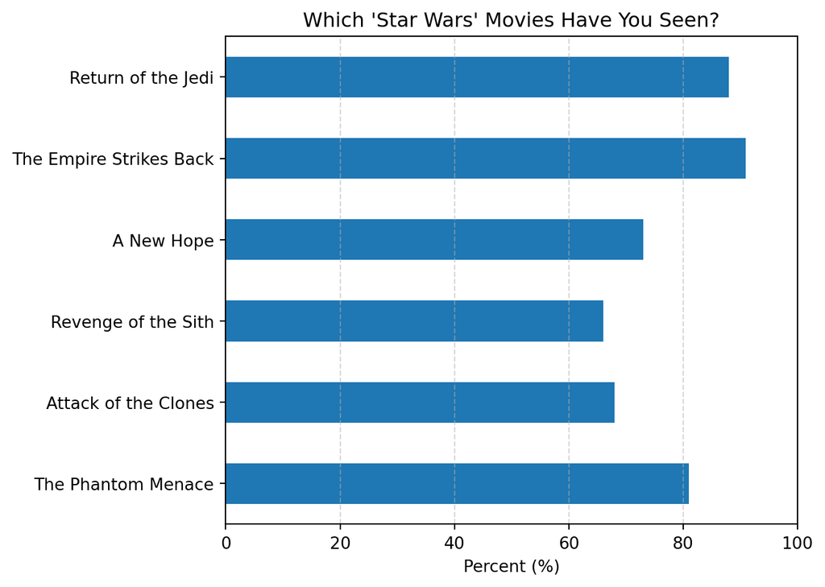

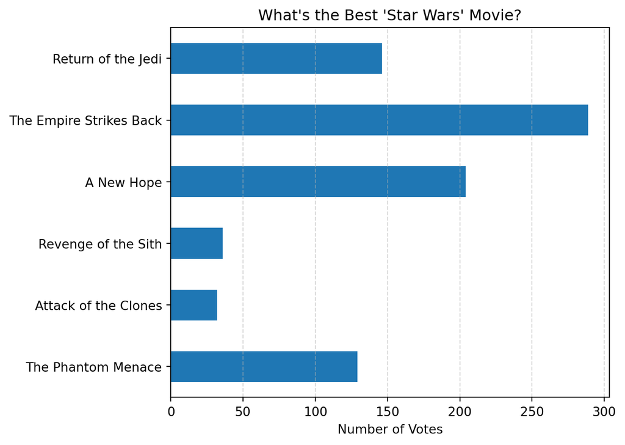

```python
import matplotlib.pyplot as plt

# Fix: Normalize 'Seen' columns by checking if they contain a movie title (not just "Yes")
seen_counts = {
    "The Phantom Menace": df["Seen_EP1"].notna().sum(),
    "Attack of the Clones": df["Seen_EP2"].notna().sum(),
    "Revenge of the Sith": df["Seen_EP3"].notna().sum(),
    "A New Hope": df["Seen_EP4"].notna().sum(),
    "The Empire Strikes Back": df["Seen_EP5"].notna().sum(),
    "Return of the Jedi": df["Seen_EP6"].notna().sum()
}

# Use only rows where the user saw at least one movie
valid_responses = df[["Seen_EP1", "Seen_EP2", "Seen_EP3", "Seen_EP4", "Seen_EP5", "Seen_EP6"]].notna().any(axis=1).sum()

seen_df = pd.DataFrame.from_dict(seen_counts, orient='index', columns=["SeenCount"])
seen_df["Percent"] = (seen_df["SeenCount"] / valid_responses * 100).round(0)

# Match 538 order
order = [
    "The Phantom Menace",
    "Attack of the Clones",
    "Revenge of the Sith",
    "A New Hope",
    "The Empire Strikes Back",
    "Return of the Jedi"
]
seen_df = seen_df.loc[order]

# Plot
seen_df["Percent"].plot(kind="barh", color="#1f77b4")
plt.title("Which 'Star Wars' Movies Have You Seen?")
plt.xlabel("Percent (%)")
plt.xlim(0, 100)
plt.grid(axis="x", linestyle="--", alpha=0.5)
plt.tight_layout()
plt.show()

# Episode order to match original release
episode_order = [
    "The Phantom Menace",
    "Attack of the Clones",
    "Revenge of the Sith",
    "A New Hope",
    "The Empire Strikes Back",
    "Return of the Jedi"
]

# Build ranking data
rank_cols = ["Rank_EP1", "Rank_EP2", "Rank_EP3", "Rank_EP4", "Rank_EP5", "Rank_EP6"]
seen_all_ranks = df[rank_cols].dropna(thresh=3).astype(float)
best_film = seen_all_ranks.idxmin(axis=1)
best_counts = best_film.value_counts()

# Rename to episode titles
rename_map = {
    "Rank_EP1": "The Phantom Menace",
    "Rank_EP2": "Attack of the Clones",
    "Rank_EP3": "Revenge of the Sith",
    "Rank_EP4": "A New Hope",
    "Rank_EP5": "The Empire Strikes Back",
    "Rank_EP6": "Return of the Jedi"
}
best_counts.index = best_counts.index.map(rename_map)

# Reindex to match episode order (fill missing with 0)
ordered_best_counts = best_counts.reindex(episode_order, fill_value=0)

# Plot
ordered_best_counts.plot(kind="barh", color="#1f77b4")
plt.title("What's the Best 'Star Wars' Movie?")
plt.xlabel("Number of Votes")
plt.grid(axis="x", linestyle="--", alpha=0.5)
plt.tight_layout()
plt.show()
```

## Task 4 - Build a machine learning model that predicts whether a person makes more than $50k. Describe your model and report the accuracy.

```python
X = df.drop(columns="IncomeOver50k")
y = df["IncomeOver50k"].astype(int)

# Encode categoricals
categorical_cols = X.select_dtypes(include="object").columns.tolist()
encoder = OrdinalEncoder(handle_unknown='use_encoded_value', unknown_value=-1)
X[categorical_cols] = encoder.fit_transform(X[categorical_cols])

# Impute
X = pd.DataFrame(SimpleImputer(strategy="mean").fit_transform(X), columns=X.columns)

# Scale
X[X.columns] = MinMaxScaler().fit_transform(X[X.columns])

# Select features
X_selected = SelectKBest(f_classif, k=20).fit_transform(X, y)

# Models
xgb = XGBClassifier(n_estimators=200, max_depth=5, subsample=0.8, colsample_bytree=0.8, use_label_encoder=False, eval_metric='logloss', learning_rate=0.005)
lgb = LGBMClassifier(n_estimators=200, max_depth=5, subsample=0.8, colsample_bytree=0.8, class_weight='balanced', learning_rate=0.005, verbose=-1 )
ensemble = VotingClassifier(estimators=[('xgb', xgb), ('lgb', lgb)], voting='soft')

X_train, X_test, y_train, y_test = train_test_split(X_selected, y, stratify=y, random_state=42)
ensemble.fit(X_train, y_train)

# Threshold tuning
probs = ensemble.predict_proba(X_test)[:, 1]
best_threshold, best_acc, best_report = 0.5, 0, ""

for t in np.linspace(0.1, 0.9, 100):
    preds = (probs > t).astype(int)
    acc = accuracy_score(y_test, preds)
    if acc > best_acc:
        best_threshold, best_acc = t, acc
        best_report = classification_report(y_test, preds, digits=4)

# Final evaluation
y_pred = (probs >= best_threshold).astype(int)
acc = accuracy_score(y_test, y_pred)
prec = precision_score(y_test, y_pred)
rec = recall_score(y_test, y_pred)
f1 = f1_score(y_test, y_pred)

print(f"Best Threshold: {best_threshold:.3f}")
print(f"Accuracy:  {acc:.4f}\nPrecision: {prec:.4f}\nRecall:    {rec:.4f}\nF1 Score:  {f1:.4f}")
print("\nClassification Report:\n", best_report)
```

```
Best Threshold: 0.553
Accuracy:  0.6453
Precision: 0.6277
Recall:    0.5514
F1 Score:  0.5871

Classification Report:
               precision    recall  f1-score   support

           0     0.6571    0.7244    0.6891       127
           1     0.6277    0.5514    0.5871       107

    accuracy                         0.6453       234
   macro avg     0.6424    0.6379    0.6381       234
weighted avg     0.6437    0.6453    0.6425       234
```